# Validation of ICD-9-CM/ICD-10-CM Codes for Automated Electronic Scoring of APACHE II, APACHE III, and SAPS II

Supplemental Material

Eric Kao, Brian Gulbis

November 30, 2016

# Patient Selection

There were 16,242 patient encounters identified which met inclusion criteria. Patients were then excluded for the following reasons:

- Pregnant: 203
- Prisoner: 77
- Missing data needed to calculate risk scores: 10,790
- Re-encounters (each patient once) : 1,782

This left a total of 3,390 eligible patients remaining. From these, a random sample of 200 patients were selected for inclusion in the study.

# Comorbidity Definitions

The following tables contain the list of ICD-9-CM and ICD-10-CM codes which were included in the author-defined comorbidity set.

Any child-codes for the codes listed were also included (i.e., 196 includes 196.0, 196.1, etc.)

ICD-9-CM Codes Used in Author-Defined Comorbidity Set for APACHE II

| Group | Comorbidity | Criteria | ICD-9-CM Code |
| --- | --- | --- | --- |
| Liver |  |  |  |
|  | Biopsy proven cirrhosis and documented portal hypertension |  | 456, 567.23, 571.2, 571.5, 572.2, 572.4, 789.59 |
|  |  | Plus | 572.3 |
|  | Past upper GI bleed attributed to portal hypertension |  | 530.82, 578.9 |
|  |  | Plus | 572.3 |
|  | Prior hepatic failure, encephalopathy, or coma |  | 070.2, 070.3, 070.41, 070.44, 070.51, 070.54, 070.7, 155, 275, 571, 573.3 |
|  |  | Or | 572.2 |
| Cardiovascular |  |  |  |
|  | Heart failure |  | 428 |
| Respiratory |  |  |  |
|  | Chronic restrictive, obstructive, or vascular disease |  | 490, 491, 492.0, 492.1, 492.2, 492.3, 492.4, 492.5, 492.6, 492.7, 492.8, 493.0, 493.1, 493.2, 493.3, 493.4, 493.5, 493.6, 493.7, 493.8, 493.90, 493.91, 494, 495, 496, 497, 498, 499, 500, 501, 502, 503… |
|  |  | Or | 440, 441.2, 441.4, 441.7, 441.9, 443.1, 443.2, 443.3, 443.4, 443.5, 443.6, 443.7, 443.8, 443.9, 447.1, 557.1, 557.9, V43.4 |
|  | Chronic hypoxia |  | 518.83, 799.02 |
|  | Chronic hypercapnia |  | 786.09 |
|  | Secondary polycythemia |  | 289.0 |
|  | Severe pulmonary hypertension |  | 416 |
|  | Respirator dependence |  | V46.11 |
| Renal |  |  |  |
|  | Receiving chronic dialysis |  | 585.6 |
| Immuno-compromised |  |  |  |
|  | Immuno-suppression therapy |  | V87.46 |
|  | Chemotherapy |  | V58.1, V87.41, E933.1 |
|  | Radiation |  | E926 |
|  | Long-term or high-dose steroids |  | V58.65 |
|  | Leukemia |  | 204, 205, 206, 207, 208 |
|  | Lymphoma |  | 200, 201, 202.0, 202.1, 202.2, 202.30, 202.31, 202.32, 202.33, 202.34, 202.35, 202.36, 202.37, 202.38, 202.5, 202.6, 202.7, 202.8, 202.9, 203.00, 203.01, 203.80, 203.81, 238.6, 273.3, V10.71, V10.72, … |
|  | AIDS |  | 042 |
|  |  | Plus | 176 |
|  |  | Or | 136.3 |
|  |  | Or | 130 |
|  |  | Or | 010, 011, 012, 013, 014, 015, 016, 017, 018 |

ICD-10-CM Codes Used in Author-Defined Comorbidity Set for APACHE II

| Group | Comorbidity | Criteria | ICD-10-CM Code |
| --- | --- | --- | --- |
| Liver |  |  |  |
|  | Biopsy proven cirrhosis and documented portal hypertension |  | I85.00, I85.01, I85.10, I85.11, K65.2, K70.30, K72.90, K72.91, K74.0, K74.60, K74.69, K76.7, R18.8 |
|  |  | Plus | K76.6 |
|  | Past upper GI bleed attributed to portal hypertension |  | K22.8, K92.2 |
|  |  | Plus | K76.6 |
|  | Prior hepatic failure, encephalopathy, or coma |  | B16.0, B16.1, B16.2, B16.9, B17.10, B17.11, B18.0, B18.0, B18.1, B18.1, B18.2, B18.2, B19.10, B19.11, B19.20, B19.21, C22.0, C22.1, C22.2, C22.7, C22.8, K70.0, K70.10, K70.30, K70.9, K71.6, K73.0, K73… |
|  |  | Or | K72.90, K72.91 |
| Cardiovascular |  |  |  |
|  | Heart failure |  | I50.1, I50.20, I50.21, I50.22, I50.23, I50.30, I50.31, I50.32, I50.33, I50.40, I50.41, I50.42, I50.43, I50.9, I50.9 |
| Respiratory |  |  |  |
|  | Chronic restrictive, obstructive, or vascular disease |  | I27.8, I27.9, J40, J41, J42, J43, J44, J45, J46, J47, J60, J61, J62, J63, J64, J65, J66, J67, J68.4, J70.1, J70.3 |
|  |  | Or | I70, I71, I73.1, I73.8, I73.9, I77.1, I79.0, I79.2, K55.1, K55.8, K55.9, Z95.8, Z95.9 |
|  | Chronic hypoxia |  | J96.10, R09.02 |
|  | Chronic hypercapnia |  | R06.00, R06.09, R06.3, R06.83, R06.89 |
|  | Secondary polycythemia |  | D75.1 |
|  | Severe pulmonary hypertension |  | I27.0 |
|  | Respirator dependence |  | Z99.11 |
| Renal |  |  |  |
|  | Receiving chronic dialysis |  | N18.6 |
| Immuno-compromised |  |  |  |
|  | Immuno-suppression therapy |  | Z92.25 |
|  | Chemotherapy |  | Z51.11, Z51.12, Z92.21 |
|  | Radiation |  | W90.0X |
|  | Long-term or high-dose steroids |  | Z79.51, Z79.52 |
|  | Leukemia |  | C95.00, C95.01, C95.02, C95.10, C95.11, C95.12, C95.90, C95.90, C95.90, C95.91, C95.91, C95.91, C95.92, C95.92, C95.92 |
|  | Lymphoma |  | C81, C82, C83, C84, C85, C88, C90.0, C90.2, C96 |
|  | AIDS |  | B20 |
|  |  | Plus | C46.0 |
|  |  | Or | B59 |
|  |  | Or | B58.01, B58.09, B58.1, B58.2, B58.3, B58.81, B58.89, B58.89, B58.9 |
|  |  | Or | A15.0, A15.4, A15.5, A15.6, A15.7, A15.8, A17.0, A17.1, A17.81, A17.82, A17.89, A17.9, A18.01, A18.02, A18.03, A18.10, A18.11, A18.12, A18.13, A18.14, A18.15, A18.16, A18.17, A18.18, A18.2, A18.31, A1… |

ICD-9-CM Codes Used in Author-Defined Comorbidity Set for APACHE III

| Comorbidity | Criteria | ICD-9-CM Code |
| --- | --- | --- |
| AIDS |  | 042 |
|  | Plus | 176 |
|  | Or | 136.3 |
|  | Or | 130 |
|  | Or | 010, 011, 012, 013, 014, 015, 016, 017, 018 |
| Hepatic failure |  | 070.2, 070.3, 070.41, 070.44, 070.51, 070.54, 070.7, 155, 275, 571, 573.3 |
| Lymphoma |  | 200, 201, 202.0, 202.1, 202.2, 202.30, 202.31, 202.32, 202.33, 202.34, 202.35, 202.36, 202.37, 202.38, 202.5, 202.6, 202.7, 202.8, 202.9, 203.00, 203.01, 203.80, 203.81, 238.6, 273.3, V10.71, V10.72, … |
| Metastatic cancer |  | 196, 197, 198, 199.0, 199.1 |
| Leukemia or multiple myeloma |  | 204, 205, 206, 207, 208 |
|  | Or | 203 |
| Immuno-suppression therapy |  | V87.46 |
| Cirrhosis |  | 456, 567.23, 571.2, 571.5, 572.2, 572.4, 789.59 |

ICD-10-CM Codes Used in Author-Defined Comorbidity Set for APACHE III

| Comorbidity | Criteria | ICD-10-CM Code |
| --- | --- | --- |
| AIDS |  | B20 |
|  | Plus | C46.0 |
|  | Or | B59 |
|  | Or | B58.01, B58.09, B58.1, B58.2, B58.3, B58.81, B58.89, B58.89, B58.9 |
|  | Or | A15.0, A15.4, A15.5, A15.6, A15.7, A15.8, A17.0, A17.1, A17.81, A17.82, A17.89, A17.9, A18.01, A18.02, A18.03, A18.10, A18.11, A18.12, A18.13, A18.14, A18.15, A18.16, A18.17, A18.18, A18.2, A18.31, A1… |
| Hepatic failure |  | B16.0, B16.1, B16.2, B16.9, B17.10, B17.11, B18.0, B18.0, B18.1, B18.1, B18.2, B18.2, B19.10, B19.11, B19.20, B19.21, C22.0, C22.1, C22.2, C22.7, C22.8, K70.0, K70.10, K70.30, K70.9, K71.6, K73.0, K73… |
| Lymphoma |  | C81, C82, C83, C84, C85, C88, C90.0, C90.2, C96 |
| Metastatic cancer |  | C77, C78, C79, C80 |
| Leukemia or multiple myeloma |  | C95.00, C95.01, C95.02, C95.10, C95.11, C95.12, C95.90, C95.90, C95.90, C95.91, C95.91, C95.91, C95.92, C95.92, C95.92 |
|  | Or | C90.00, C90.00, C90.01, C90.02 |
| Immuno-suppression therapy |  | Z92.25 |
| Cirrhosis |  | I85.00, I85.01, I85.10, I85.11, K65.2, K70.30, K72.90, K72.91, K74.0, K74.60, K74.69, K76.7, R18.8 |

ICD-9-CM Codes Used in Author-Defined Comorbidity Set for SAPS II

| Comorbidity | Criteria | ICD-9-CM Code |
| --- | --- | --- |
| AIDS |  | 042 |
|  | Plus | 176 |
|  | Or | 136.3 |
|  | Or | 130 |
|  | Or | 010, 011, 012, 013, 014, 015, 016, 017, 018 |
| Metastatic cancer |  | 196, 197, 198, 199.0, 199.1 |
| Hematologic malignancy |  | 204, 205, 206, 207, 208 |
|  | Or | 200, 201, 202.0, 202.1, 202.2, 202.30, 202.31, 202.32, 202.33, 202.34, 202.35, 202.36, 202.37, 202.38, 202.5, 202.6, 202.7, 202.8, 202.9, 203.00, 203.01, 203.80, 203.81, 238.6, 273.3, V10.71, V10.72, … |
|  | Or | 203 |

ICD-10-CM Codes Used in Author-Defined Comorbidity Set for SAPS II

| Comorbidity | Criteria | ICD-10-CM Code |
| --- | --- | --- |
| AIDS |  | B20 |
|  | Plus | C46.0 |
|  | Or | B59 |
|  | Or | B58.01, B58.09, B58.1, B58.2, B58.3, B58.81, B58.89, B58.89, B58.9 |
|  | Or | A15.0, A15.4, A15.5, A15.6, A15.7, A15.8, A17.0, A17.1, A17.81, A17.82, A17.89, A17.9, A18.01, A18.02, A18.03, A18.10, A18.11, A18.12, A18.13, A18.14, A18.15, A18.16, A18.17, A18.18, A18.2, A18.31, A1… |
| Metastatic cancer |  | C77, C78, C79, C80 |
| Hematologic malignancy |  | C95.00, C95.01, C95.02, C95.10, C95.11, C95.12, C95.90, C95.90, C95.90, C95.91, C95.91, C95.91, C95.92, C95.92, C95.92 |
|  | Or | C81, C82, C83, C84, C85, C88, C90.0, C90.2, C96 |
|  | Or | C90.00, C90.00, C90.01, C90.02 |

# Statistical Methods

Data processing, risk score calculations, and statistical analysis were performed using R version 3.3.2 (2016-10-31) (R Core Team (2016)). The `icd` package (Wasey (2016)) was used to cross-reference patient diagnosis codes with comorbidity set diagnosis codes.

R Core Team. 2016. *R: A Language and Environment for Statistical Computing*. Vienna, Austria: R Foundation for Statistical Computing. https://www.R-project.org/.

Wasey, Jack O. 2016. *Icd: Tools for Working with Icd-9 and Icd-10 Codes, and Finding Comorbidities*. https://CRAN.R-project.org/package=icd.

Continuous data were analyzed using a paired t-test and Wilcoxon signed rank test. The p-value was then adjusted using the Benjamini and Hochberg method to account for performing multiple comparisons.

A univarite linear regression model was fit using the risk score from each comorbidity set to predict the risk score for the manual review set.

# Supplemental Results

The following tables contain the mean and median risk score calculated using each of the eight comorbidity sets, as well as the manual review set. A comparison of the means and medians was performed.

The adjusted p-value and 95% confidence intervals (CI) are reported for the t-test and Wilcoxon rank sum (denoted by the *)

## Primary Endpoint

APACHE II Score

| Tool | Mean | SD | P-value | 95% CI | Median | IQR | P-value* | 95% CI* |
| --- | --- | --- | --- | --- | --- | --- | --- | --- |
| AHRQ | 20.20 | 6.858 | 0.131 | 0.014 - 0.646 | 20 | 15 - 24 | 0.168 | 0 - 2 |
| AHRQ+DRG | 19.79 | 6.832 | 0.619 | -0.397 - 0.237 | 19 | 15 - 24 | 0.518 | -1.5 - 0 |
| Authors | 20.05 | 6.910 | 0.425 | -0.138 - 0.498 | 20 | 15 - 24 | 0.504 | 0 - 2 |
| Authors+DRG | 19.65 | 6.867 | 0.341 | -0.535 - 0.095 | 19 | 15 - 24 | 0.271 | -1.5 - 0 |
| Elixhauser | 20.18 | 6.927 | 0.131 | 0.001 - 0.619 | 20 | 15 - 24 | 0.168 | 0 - 2 |
| Elixhauser+DRG | 19.77 | 6.900 | 0.619 | -0.409 - 0.209 | 19 | 15 - 24 | 0.518 | -1.5 - 0 |
| Manual | 19.87 | 7.021 | NA | NA | 19 | 15 - 24.25 | NA | NA |
| Quan | 20.18 | 6.927 | 0.131 | 0.001 - 0.619 | 20 | 15 - 24 | 0.168 | 0 - 2 |
| Quan+DRG | 19.78 | 6.892 | 0.619 | -0.399 - 0.219 | 19 | 15 - 24 | 0.518 | -1.5 - 0 |

APACHE III Score

| Tool | Mean | SD | P-value | 95% CI | Median | IQR | P-value* | 95% CI* |
| --- | --- | --- | --- | --- | --- | --- | --- | --- |
| AHRQ | 85.715 | 29.300 | 0.007 | 0.302 - 1.518 | 82.0 | 65.8 - 103.2 | 0.012 | 3 - 13 |
| AHRQ+DRG | 85.555 | 29.259 | 0.012 | 0.169 - 1.331 | 82.0 | 65 - 103.2 | 0.018 | 1.5 - 11.5 |
| Authors | 85.715 | 29.300 | 0.007 | 0.302 - 1.518 | 82.0 | 65.8 - 103.2 | 0.012 | 3 - 13 |
| Authors+DRG | 85.555 | 29.259 | 0.012 | 0.169 - 1.331 | 82.0 | 65 - 103.2 | 0.018 | 1.5 - 11.5 |
| Elixhauser | 85.715 | 29.300 | 0.007 | 0.302 - 1.518 | 82.0 | 65.8 - 103.2 | 0.012 | 3 - 13 |
| Elixhauser+DRG | 85.555 | 29.259 | 0.012 | 0.169 - 1.331 | 82.0 | 65 - 103.2 | 0.018 | 1.5 - 11.5 |
| Manual | 84.805 | 28.998 | NA | NA | 81.5 | 63.8 - 103 | NA | NA |
| Quan | 85.715 | 29.300 | 0.007 | 0.302 - 1.518 | 82.0 | 65.8 - 103.2 | 0.012 | 3 - 13 |
| Quan+DRG | 85.555 | 29.259 | 0.012 | 0.169 - 1.331 | 82.0 | 65 - 103.2 | 0.018 | 1.5 - 11.5 |

SAPS II Score

| Tool | Mean | SD | P-value | 95% CI | Median | IQR | P-value* | 95% CI* |
| --- | --- | --- | --- | --- | --- | --- | --- | --- |
| AHRQ | 37.12 | 14.564 | 0.182 | -0.085 - 0.445 | 36.0 | 26 - 47 | 0.518 | -0.5 - 9.5 |
| AHRQ+DRG | 37.12 | 14.564 | 0.182 | -0.085 - 0.445 | 36.0 | 26 - 47 | 0.518 | -0.5 - 9.5 |
| Authors | 37.12 | 14.564 | 0.182 | -0.085 - 0.445 | 36.0 | 26 - 47 | 0.518 | -0.5 - 9.5 |
| Authors+DRG | 37.12 | 14.564 | 0.182 | -0.085 - 0.445 | 36.0 | 26 - 47 | 0.518 | -0.5 - 9.5 |
| Elixhauser | 37.12 | 14.564 | 0.182 | -0.085 - 0.445 | 36.0 | 26 - 47 | 0.518 | -0.5 - 9.5 |
| Elixhauser+DRG | 37.12 | 14.564 | 0.182 | -0.085 - 0.445 | 36.0 | 26 - 47 | 0.518 | -0.5 - 9.5 |
| Manual | 36.94 | 14.449 | NA | NA | 34.5 | 26 - 46.2 | NA | NA |
| Quan | 37.12 | 14.564 | 0.182 | -0.085 - 0.445 | 36.0 | 26 - 47 | 0.518 | -0.5 - 9.5 |
| Quan+DRG | 37.12 | 14.564 | 0.182 | -0.085 - 0.445 | 36.0 | 26 - 47 | 0.518 | -0.5 - 9.5 |

## Secondary Endpoints

Predicted Mortality using SAPS II

| Tool | Mean | SD | P-value | 95% CI | Median | IQR | P-value* | 95% CI* |
| --- | --- | --- | --- | --- | --- | --- | --- | --- |
| AHRQ | 0.251 | 0.230 | 0.069 | 0 - 0.008 | 0.181 | 0.1 - 0.4 | 0.08 | -0.009 - 0.186 |
| AHRQ+DRG | 0.251 | 0.230 | 0.069 | 0 - 0.008 | 0.181 | 0.1 - 0.4 | 0.08 | -0.009 - 0.186 |
| Authors | 0.251 | 0.230 | 0.069 | 0 - 0.008 | 0.181 | 0.1 - 0.4 | 0.08 | -0.009 - 0.186 |
| Authors+DRG | 0.251 | 0.230 | 0.069 | 0 - 0.008 | 0.181 | 0.1 - 0.4 | 0.08 | -0.009 - 0.186 |
| Elixhauser | 0.251 | 0.230 | 0.069 | 0 - 0.008 | 0.181 | 0.1 - 0.4 | 0.08 | -0.009 - 0.186 |
| Elixhauser+DRG | 0.251 | 0.230 | 0.069 | 0 - 0.008 | 0.181 | 0.1 - 0.4 | 0.08 | -0.009 - 0.186 |
| Manual | 0.248 | 0.228 | NA | NA | 0.160 | 0.1 - 0.4 | NA | NA |
| Quan | 0.251 | 0.230 | 0.069 | 0 - 0.008 | 0.181 | 0.1 - 0.4 | 0.08 | -0.009 - 0.186 |
| Quan+DRG | 0.251 | 0.230 | 0.069 | 0 - 0.008 | 0.181 | 0.1 - 0.4 | 0.08 | -0.009 - 0.186 |

Number of Comorbidities per Patient using APACHE II

| Tool | Mean | SD | P-value | 95% CI | Median | IQR | P-value* | 95% CI* |
| --- | --- | --- | --- | --- | --- | --- | --- | --- |
| AHRQ | 0.760 | 0.731 | 0.051 | 0.037 - 0.273 | 1 | 0 - 1 | 0.052 | 0 - 1 |
| AHRQ+DRG | 0.595 | 0.673 | 0.862 | -0.124 - 0.104 | 0 | 0 - 1 | 0.912 | 0 - 0 |
| Authors | 0.690 | 0.719 | 0.300 | -0.033 - 0.203 | 1 | 0 - 1 | 0.255 | 0 - 0.5 |
| Authors+DRG | 0.530 | 0.641 | 0.300 | -0.187 - 0.037 | 0 | 0 - 1 | 0.329 | -0.5 - 0 |
| Elixhauser | 0.745 | 0.737 | 0.051 | 0.023 - 0.257 | 1 | 0 - 1 | 0.052 | 0 - 0.5 |
| Elixhauser+DRG | 0.575 | 0.661 | 0.792 | -0.141 - 0.081 | 0 | 0 - 1 | 0.784 | 0 - 0 |
| Manual | 0.605 | 0.722 | NA | NA | 0 | 0 - 1 | NA | NA |
| Quan | 0.750 | 0.742 | 0.051 | 0.028 - 0.262 | 1 | 0 - 1 | 0.052 | 0 - 0.5 |
| Quan+DRG | 0.585 | 0.667 | 0.828 | -0.132 - 0.092 | 0 | 0 - 1 | 0.815 | 0 - 0 |

The following table contains the number of patients with different comorbidities identified by the comorbidity sets when compared with manual review. For APACHE II, this was counted as the number of patients where a comorbidity was identified by ICD or by manual, but not both. For APACHE III and SAPS II, this was counted as the number of patients where the primary comorbidity identified by ICD coding varied from the primary comorbidity identified by manual review.

Proportion of Patients with Differing Comorbidities

| Tool | APACHE II, n (%) | APACHE III, n (%) | SAPS II, n (%) |
| --- | --- | --- | --- |
| AHRQ | 72 (36) | 32 (16) | 8 (4) |
| AHRQ+DRG | 68 (34) | 31 (15.5) | 8 (4) |
| Authors | 71 (35.5) | 32 (16) | 8 (4) |
| Authors+DRG | 68 (34) | 31 (15.5) | 8 (4) |
| Elixhauser | 70 (35) | 32 (16) | 8 (4) |
| Elixhauser+DRG | 66 (33) | 31 (15.5) | 8 (4) |
| Quan | 70 (35) | 32 (16) | 8 (4) |
| Quan+DRG | 67 (33.5) | 31 (15.5) | 8 (4) |

## Linear Regression Models

Linear Regression Models for APACHE II

| Tool | r.squared | adj.r.squared | sigma | statistic | p.value | df | logLik | AIC | BIC | deviance | df.residual |
| --- | --- | --- | --- | --- | --- | --- | --- | --- | --- | --- | --- |
| AHRQ | 0.897 | 0.896 | 2.262 | 1718.366 | 0 | 2 | -446.066 | 898.132 | 908.026 | 1013.432 | 198 |
| AHRQ+DRG | 0.896 | 0.896 | 2.269 | 1706.410 | 0 | 2 | -446.692 | 899.383 | 909.278 | 1019.794 | 198 |
| Authors | 0.896 | 0.896 | 2.269 | 1706.705 | 0 | 2 | -446.676 | 899.352 | 909.247 | 1019.636 | 198 |
| Authors+DRG | 0.897 | 0.897 | 2.257 | 1726.889 | 0 | 2 | -445.622 | 897.244 | 907.139 | 1008.945 | 198 |
| Elixhauser | 0.902 | 0.901 | 2.203 | 1822.143 | 0 | 2 | -440.792 | 887.584 | 897.479 | 961.371 | 198 |
| Elixhauser+DRG | 0.902 | 0.901 | 2.208 | 1814.341 | 0 | 2 | -441.179 | 888.358 | 898.253 | 965.098 | 198 |
| Quan | 0.902 | 0.901 | 2.203 | 1822.143 | 0 | 2 | -440.792 | 887.584 | 897.479 | 961.371 | 198 |
| Quan+DRG | 0.901 | 0.901 | 2.213 | 1804.009 | 0 | 2 | -441.694 | 889.387 | 899.282 | 970.079 | 198 |

Fitted Values vs. Residuals for APACHE II Linear Regression Models

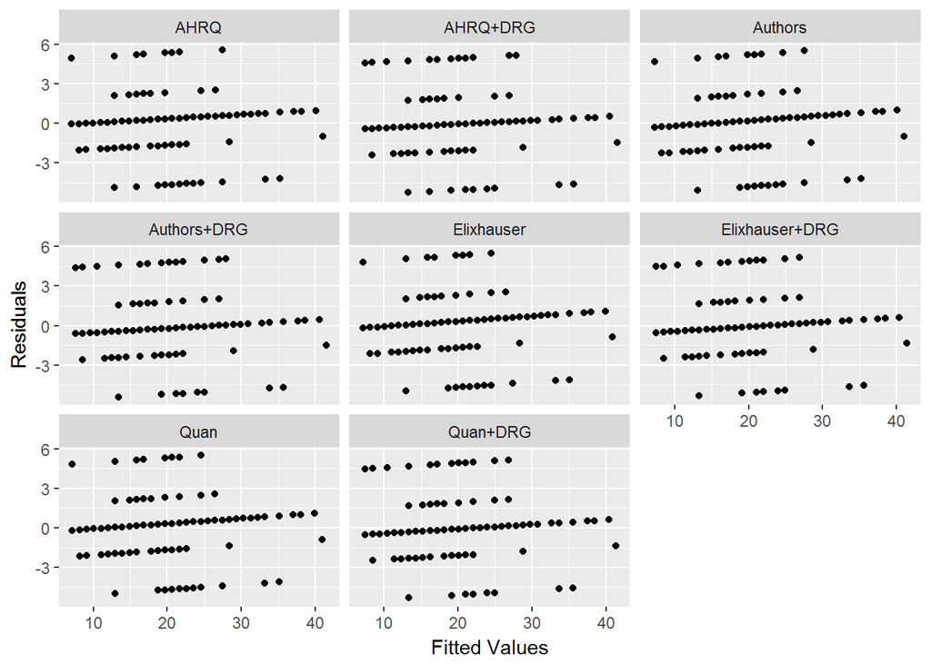

Linear Regression Models for APACHE III

| Tool | r.squared | adj.r.squared | sigma | statistic | p.value | df | logLik | AIC | BIC | deviance | df.residual |
| --- | --- | --- | --- | --- | --- | --- | --- | --- | --- | --- | --- |
| AHRQ | 0.978 | 0.978 | 4.328 | 8735.812 | 0 | 2 | -575.802 | 1157.604 | 1167.499 | 3708.786 | 198 |
| AHRQ+DRG | 0.980 | 0.980 | 4.140 | 9564.716 | 0 | 2 | -566.929 | 1139.858 | 1149.753 | 3393.891 | 198 |
| Authors | 0.978 | 0.978 | 4.328 | 8735.812 | 0 | 2 | -575.802 | 1157.604 | 1167.499 | 3708.786 | 198 |
| Authors+DRG | 0.980 | 0.980 | 4.140 | 9564.716 | 0 | 2 | -566.929 | 1139.858 | 1149.753 | 3393.891 | 198 |
| Elixhauser | 0.978 | 0.978 | 4.328 | 8735.812 | 0 | 2 | -575.802 | 1157.604 | 1167.499 | 3708.786 | 198 |
| Elixhauser+DRG | 0.980 | 0.980 | 4.140 | 9564.716 | 0 | 2 | -566.929 | 1139.858 | 1149.753 | 3393.891 | 198 |
| Quan | 0.978 | 0.978 | 4.328 | 8735.812 | 0 | 2 | -575.802 | 1157.604 | 1167.499 | 3708.786 | 198 |
| Quan+DRG | 0.980 | 0.980 | 4.140 | 9564.716 | 0 | 2 | -566.929 | 1139.858 | 1149.753 | 3393.891 | 198 |

Fitted Values vs. Residuals for APACHE III Linear Regression Models

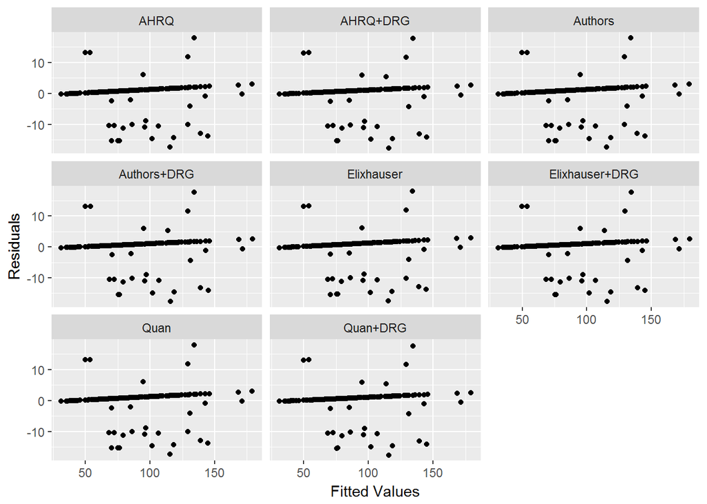

Linear Regression Models for SAPS II

| Tool | r.squared | adj.r.squared | sigma | statistic | p.value | df | logLik | AIC | BIC | deviance | df.residual |
| --- | --- | --- | --- | --- | --- | --- | --- | --- | --- | --- | --- |
| AHRQ | 0.983 | 0.983 | 1.889 | 11449.91 | 0 | 2 | -409.948 | 825.897 | 835.792 | 706.218 | 198 |
| AHRQ+DRG | 0.983 | 0.983 | 1.889 | 11449.91 | 0 | 2 | -409.948 | 825.897 | 835.792 | 706.218 | 198 |
| Authors | 0.983 | 0.983 | 1.889 | 11449.91 | 0 | 2 | -409.948 | 825.897 | 835.792 | 706.218 | 198 |
| Authors+DRG | 0.983 | 0.983 | 1.889 | 11449.91 | 0 | 2 | -409.948 | 825.897 | 835.792 | 706.218 | 198 |
| Elixhauser | 0.983 | 0.983 | 1.889 | 11449.91 | 0 | 2 | -409.948 | 825.897 | 835.792 | 706.218 | 198 |
| Elixhauser+DRG | 0.983 | 0.983 | 1.889 | 11449.91 | 0 | 2 | -409.948 | 825.897 | 835.792 | 706.218 | 198 |
| Quan | 0.983 | 0.983 | 1.889 | 11449.91 | 0 | 2 | -409.948 | 825.897 | 835.792 | 706.218 | 198 |
| Quan+DRG | 0.983 | 0.983 | 1.889 | 11449.91 | 0 | 2 | -409.948 | 825.897 | 835.792 | 706.218 | 198 |

Fitted Values vs. Residuals for SAPS II Linear Regression Models

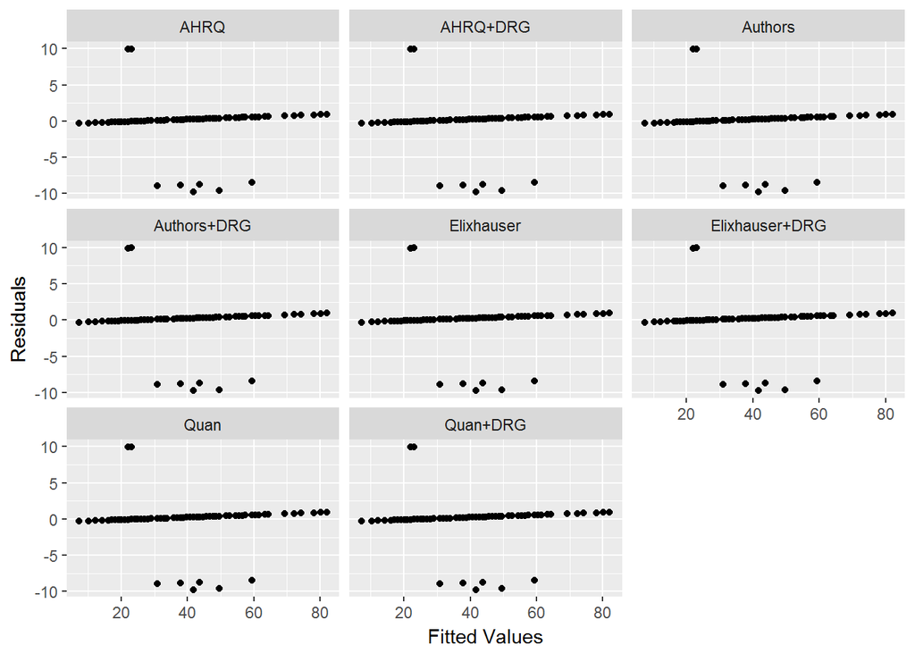